# Crecimiento exponencial

Tercer semana. Ecología de Poblaciones Silvestres

## Contenido

- Teoría del crecimiento exponencial
- Dudas con instalación del ambiente de trabajo II.
- Paso a paso del tutorial con **Rmarkdown**.
- Tarea 01. Presentación.
- Metas para la próxima semana

## ¿Qué es una ecuación diferencial?

Formalmente, una ecuación diferencial es aquella donde:

> *la incógnita es una función de una o varias variables Y si en la ecuación aparece una o más derivadas de la incógnita.*

En palabras simples:

> *es una ecuación, donde el valor de la variable dependiente está en función de otras variables y la tasa de cambio de la misma variable dependiente.*

## Notación diferencial

La mayor diferencia del crecimiento geométrico con el exponencial, es la escala de tiempo en la que trabajamos.

- El crecimiento geométrico trabaja con escala de tiempo discreto (Números naturales).
- El crecimiento exponencial trabaja con escalas de tiempo infinitesimales (infinitamente pequeñas).

Para representar escalas de tiempo infinitesimales, cambiamos el símbolo \(\Delta\), por una *de* minúscula (\(d\)).

## Deducción del crecimiento exponencial

**En palabras**:

*La tasa de crecimiento poblacional es proporcional al tamaño de la población.*

Es decir, una población crece rápido si tiene muchos individuos. En contraste con una población con pocos individuos, donde el crecimiento será más lento.

- Se dice que un valor es proporcional a otro, si su cociente es una constante:

\[ \frac{dN/dt}{N} = \mathrm{r_m} \]

## Deducción del crecimiento exponencial

Despejando la tasa de crecimiento, observamos una patrón similar al desarrollo de la ecuación de crecimiento geométrico.

\[ \frac{dN}{dt} = \mathrm{r_m}N \]

Donde \(\mathrm{r_m}\) es la *tasa intrínseca de crecimiento* (equivale a la diferencia entre la tasa de natalidad instantánea menos la tasa de mortalidad instantánea).

Esta expresión es una de las ecuaciones diferenciales más sencillas de resolver. Se utiliza el método de *separación de variables*.

## Deducción del crecimiento exponencial

El método de separación de variables consiste en dejar todos los términos de la incógnita de un lado, y los términos de la variable independiente (\(t\)) del otro lado de la igualdad:

\[ \frac{1}{N} \times \frac{dN}{dt}=\mathrm{r_m} \]

Luego se integra ambos lados con respecto de la variable independiente:

\[ \int \left( \frac{1}{N} \times \frac{dN}{dt}\right)\,dt=\int \mathrm{r_m}\,dt \]

## Deducción del crecimiento exponencial

Observe que del lado izquierdo los diferenciales se cancelan: \[ \begin{split} \int \frac{dN}{N}&=\mathrm{r_m} t + c\\ \ln N & = \mathrm{r_m} t + c\\ \end{split} \]

Se despeja \(N\), y se obtiene \(N=Ce^{\mathrm{r_m} t}\). Luego, cuando \(N=N_0\) entonces \(t=0\); por lo que la expresión se simplifica a \(N_0 = C e^0 = C\). Dando como resultado la expresión

\[ N = N_0 e^{\mathrm{r_m} t} \]

## Relación del crecimiento exponencial con el geométrico

Las constantes que determinan la velocidad del crecimiento están relacionadas.

\[ \begin{split} \lambda &= e^{\mathrm{r_m}}\\ \mathrm{r_m} &= \ln\lambda\\ \end{split} \]

Esto es interesante porque \(\mathrm{r_m}\) es fácilmente escalable. Por ejemplo, si nos dan la tasa intrínseca de crecimiento en días, pero queremos utilizarla en semanas, hacemos que \(\mathrm{r_s}=7\times \mathrm{r_d}\).

## Ejemplo 1

En un cultivo de una especie presa, para un programa de reintroducción de su depredador, se cuenta con un presupuesto de 2,000,000 CRC para mejorar la producción de éstos animales.

El diseño experimental requiere de 40 recipientes acondicionados con diferentes tratamientos.

Las presas tienen una tasa de crecimiento intrínseco de \(r_m = 0.098d^{-1}\).

El inóculo inicial es de 1000 individuos por recipiente. Si se sabe que el costo de mantenimiento por organismo-día es de 0.5 CRC por día:

*¿Cuántos organismos por recipiente se pueden cultivar sin sobrepasar el dinero disponible? ¿Cuánto tiempo, en días, se necesitan para alcanzar esa cantidad?*

## Ejemplo 1

Encontrar el mínimo: *Presupuesto del experimento menos el costo es igual a cero*

El costo está dado por:

- \(a\): el costo de mantenimiento diario del organismo: CRC por individuo-día.
- La cantidad de organismos posibles del experimento, \(N\). Cuyo número está limitado por el presupuesto.
- La tasa intrínseca de crecimiento \(r_m = 0.098d^{-1}\).
- El inóculo inicial \(N_0 = 1000\).
- La cantidad de tanques experimentales (40 en total).
- \(t\): el tiempo de generación.

## Ejemplo 1

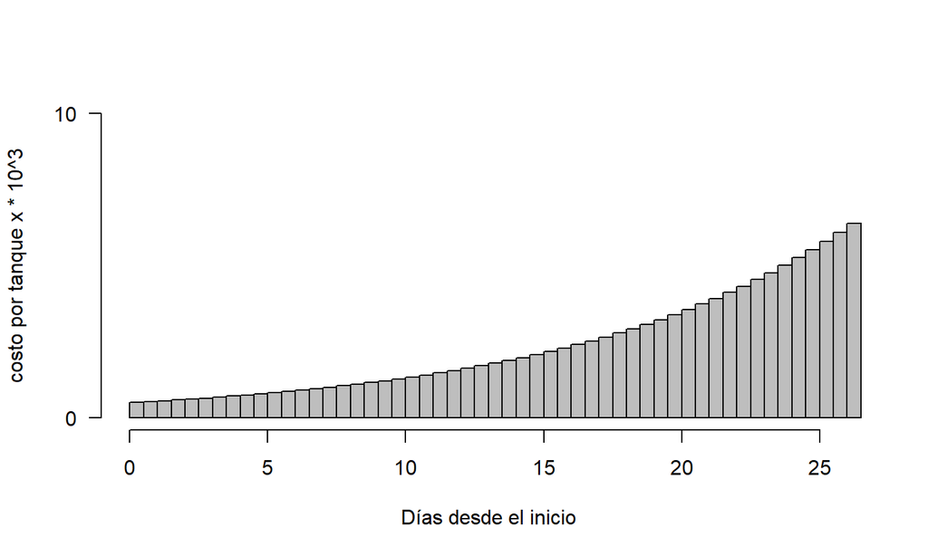

Represencación del costo por tanque, en pequeños intervalos de tiempo

## Ejemplo 1

Esto equivale a:

\[ C = \lim_{\Delta t \to 0} \sum_{i=1}^{b} \mathrm{a}N(t_i)\Delta t = \int_0^b\mathrm{a}N(t)dt \]

Que equivale a resolver:

\[ \begin{split} C &= \mathrm{a}N_o\int_0^b e^{rt}\ dt\\ C &= \mathrm{a}N_0(\frac{e^{b r}}{r}-\frac{1}{r})\\ \end{split} \]

## Ejemplo 1

La solución equivale a minimizar la siguiente función:

\[ \underset{t \in \mathbb{R}^+}{\text{minimizar}} \, \left| 2\times10^6 - 40 \times\mathrm{a}N_0(\frac{e^{br}}{r}-\frac{1}{r}) \right| \]

## Ejercicio en clase

De acuerdo con Illman et al (2000) un gramo de *Chlorella emersonii* puede contener 29 kJ/g (energía por gramo). Si la tasa intrínseca es de 0.99 1/d, ¿cuántos gramos de *Chlorella* necesito para producir 5000 kJ? ¿Cuál es el tiempo de producción? Asuma un crecimiento exponencial, y un inóculo inicial con \(N_0 = 1\mu \mathrm{g}\) de *Chlorella*.

Illman, et al. (2000). Increase in Chlorella strains calorific values when grown in low nitrogen medium. Enzyme and Microbial Technology, 27(8), 631–635.

## Ajuste de la curva de crecimiento exponencial

Podemos utilizar las propiedades de los logaritmos para estimar fácilmente los parámetros de la curva de crecimiento:

\[ \ln \left( N_t \right) = \ln \left( N_0 \right) + \mathrm{r_m}t \]

## Datos en escala natural y logarítmica

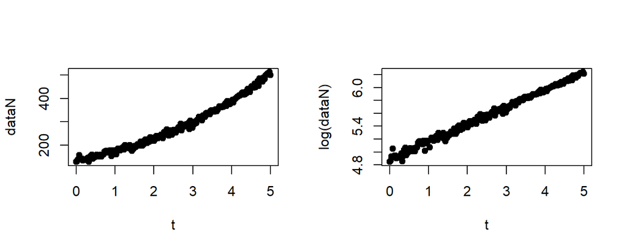

Los valores que se utilizaron para construir la curva son:

- \(N_0 = 132\) y \(r_m = 0.27\)
- … pero no lo sabemos!

## Ajuste de la curva de crecimiento exponencial

```r
out <- glm(
  formula = log(N) ~ t,
  family = gaussian(link = "identity"),
  data = data
  )

  outCI <- confint(out)
  outCI
```

```
##                 2.5 %    97.5 %
## (Intercept) 4.8740859 4.8930085
## t           0.2663977 0.2729444
```

## Verificar valores

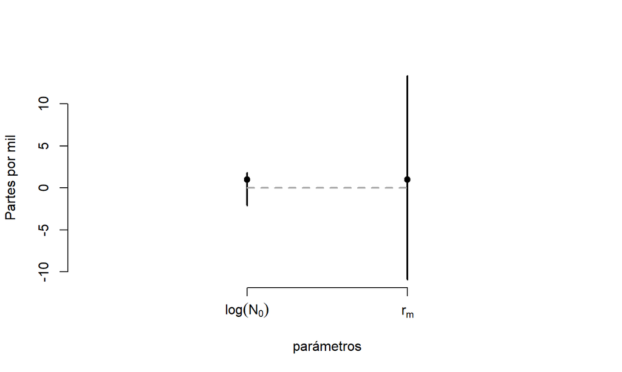

## Graficar

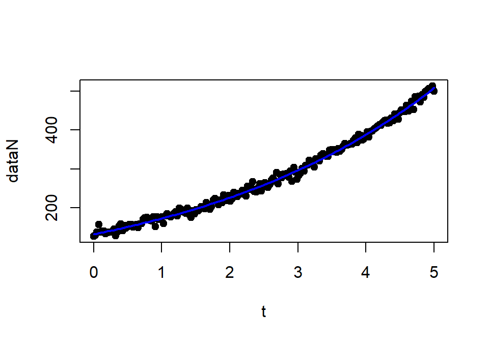

```r
plot(t,dataN,type="p", pch=21,bg=1)
curve(exp(coef(out)[1])*exp(coef(out)[2]*x),
      add = TRUE,
      col = "blue", lwd = 2)
```

## Dudas con instalación del ambiente de trabajo II

## Paso a paso del tutorial con **Rmarkdown**

## Tarea 01. Presentación

## Metas para la próxima semana

- Descargar **Libreoffice**.
- Entregar la Tarea 01. **Fecha límite** 2019-03-13 (YYYY-MM-DD), 23:59 horas.
- Subir dudas sobre tarea o materia al foro de GitHub.